# Data visualisation

박신형

2020 10 3

# Chapter 1. 데이터 시각화

Sin Hyung Park 10/5/2020

> *“간단한 그래프는 데이터 분석가에게 다른 어떤 것보다도 많은 정보를 제공한다.”*

> — *존 튜키(John Tukey)*

### 목차

- 1.1 들어가기
- 1.2 첫 단계
- 1.3 심미성 매핑
- 1.4 자주 일어나는 문제들
- 1.5 facet
- 1.6 기하 객체
- 1.7 통계적 변환
- 1.8 위치 조정
- 1.9 좌표계
- 1.10 그래프 레이어 문법

## 1.1 들어가기

이 장에서는 ggplot를 이용하여 데이터를 시각화하는 법을 배울 것이다.

- 1.1.1 준비하기

install.packages(“tidyverse”) library(tidyverse)

## 1.2 첫 단계

*Q. 엔진이 큰 차가 작은 차보다 연료를 더 많이 소비하는가?*

- 1.2.1 mpg 데이터프레임

```r
ggplot2::mpg
```

```
## # A tibble: 234 x 11
##    manufacturer model    displ  year   cyl trans   drv     cty   hwy fl    class
##    <chr>        <chr>    <dbl> <int> <int> <chr>   <chr> <int> <int> <chr> <chr>
##  1 audi         a4         1.8  1999     4 auto(l~ f        18    29 p     comp~
##  2 audi         a4         1.8  1999     4 manual~ f        21    29 p     comp~
##  3 audi         a4         2    2008     4 manual~ f        20    31 p     comp~
##  4 audi         a4         2    2008     4 auto(a~ f        21    30 p     comp~
##  5 audi         a4         2.8  1999     6 auto(l~ f        16    26 p     comp~
##  6 audi         a4         2.8  1999     6 manual~ f        18    26 p     comp~
##  7 audi         a4         3.1  2008     6 auto(a~ f        18    27 p     comp~
##  8 audi         a4 quat~   1.8  1999     4 manual~ 4        18    26 p     comp~
##  9 audi         a4 quat~   1.8  1999     4 auto(l~ 4        16    25 p     comp~
## 10 audi         a4 quat~   2    2008     4 manual~ 4        20    28 p     comp~
## # ... with 224 more rows
```

- displ : 엔진 크기 (단위 : 리터)
- hwy : 고속도로에서의 자동차 연비(단위 : 갤런당 마일, mpg), 같은 거리를 주행할 때, 연비가 낮은 차는 연비가 높은 차보다 연료를 더 많이 소비한다.

**1.2.2 ggplot 생성하기**

install.packages(c(“ggplot2”, “plyr”)) library(ggplot2)

```r
library(ggplot2)
ggplot(data = mpg) +
  geom_point(mapping = aes(x = displ, y = hwy))
```

*용어설명*

- 기하객체: geometric object - 줄여서 geom
- 미적속성: aesthetics property - aes()

**그래프 작성 템플릿**

- **ggplot(data = <데이터>) + <지옴함수>(mapping = aes(<매핑모음>)**

*1.2.4 연습문제*

1. ggplot(data = mpg)를 실행하라. 무엇이 나타나는가?
2. mpg는 행이 몇개인가? 열은 몇 개인가?
- **?mpg** or **ggplot2::mpg**
3. drv 변수는 무엇을 나타내는가? ?mpg로 도움말 페이지를 참고하여 알아보자.
- ?mpg
- **drv** : the type of drive train, where f = front-wheel drive, r = rear wheel drive, 4 = 4wd
4. hwy 대 cyl의 산점도를 만들어라

   ```
     ggplot(data = mpg)+
       geom_point(mapping = aes(x = hwy, y = cyl))
   ```

5. class 대 dvr 산점도를 만들면 어떻게 되는가? 이 플롯이 유용하지 않은 이유는 무엇인가?

   ```
     ggplot(data = mpg)+
       geom_point(mapping = aes(x = class, y = dvr))
   ```

## 1.3 심미성 매핑

```r
ggplot(data = mpg) +
  geom_point(mapping = aes(x = displ, y = hwy))
```

- 선형 추세를 벗어나는 점들은 무엇일까?? –> 가설 : 하이브리드 차량이 아닐까?
- 변수를 추가해서 확인해보자!
- class 별로 색깔 구분을 해보자!

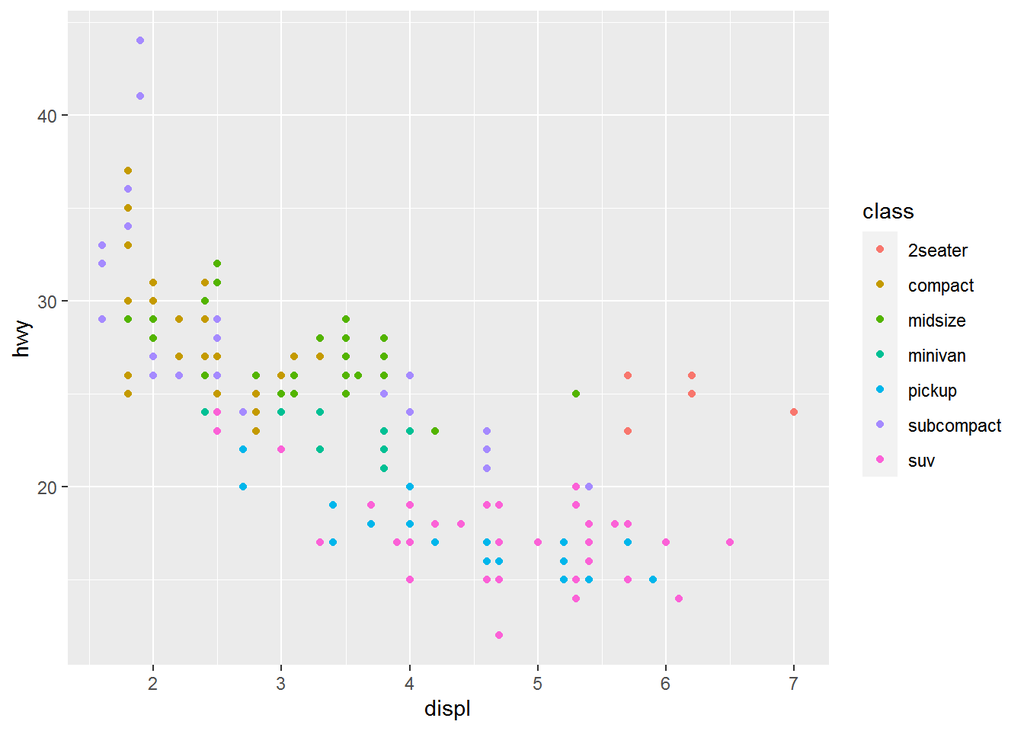

```r
ggplot(data = mpg) +
  geom_point(mapping = aes(x = displ, y = hwy, color = class))
```

- 이를 통해 이상값 중 다수가 2인승 차임을 보여준다.
- 이 차들은 하이브리드 차가 아닌 스포츠카로 판단된다.
- 점의 크기로 구분을 해보면 어떨까?

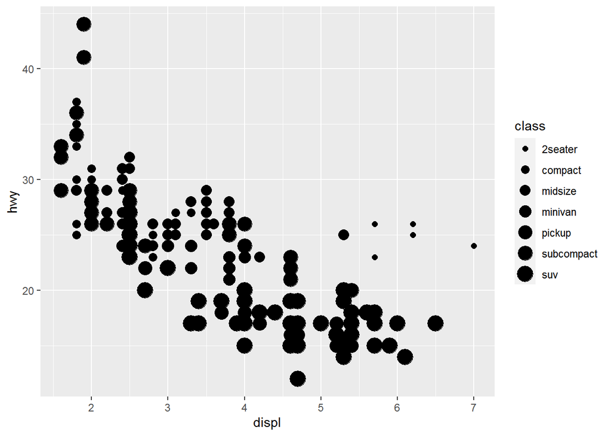

```r
ggplot(data = mpg) +
  geom_point(mapping = aes(x = displ, y = hwy, size = class))
```

- 점의 투명도로 구분을 해보면?

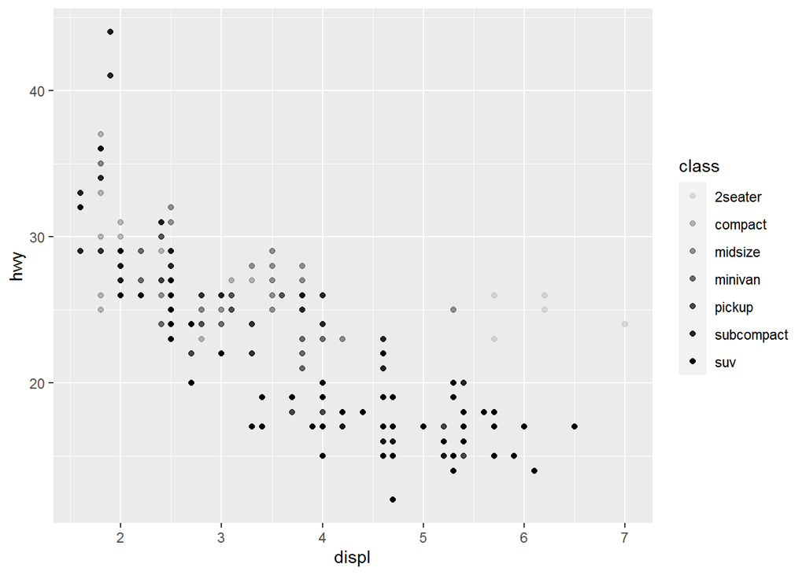

```r
ggplot(data = mpg) +
  geom_point(mapping = aes(x = displ, y = hwy, alpha = class))
```

- 점의 모양별로 구분을 해보면?

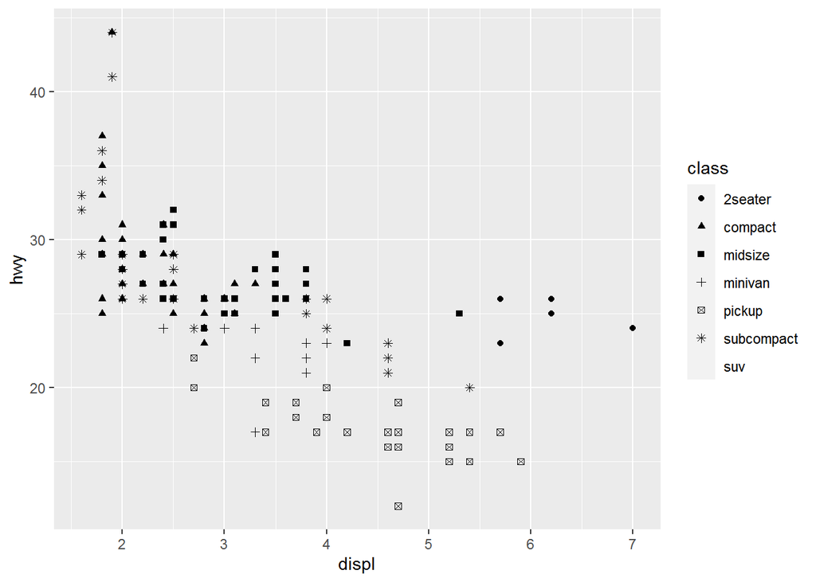

```r
ggplot(data = mpg) +
  geom_point(mapping = aes(x = displ, y = hwy, shape = class))
```

- ggplot2는 한번에 여섯 개의 모양만 사용

- ggplot2는 기본 셋팅값으로 나머지를 처리한다.
- 지옴 심미성의 속성을 수동으로 설정할 수 도 있다.

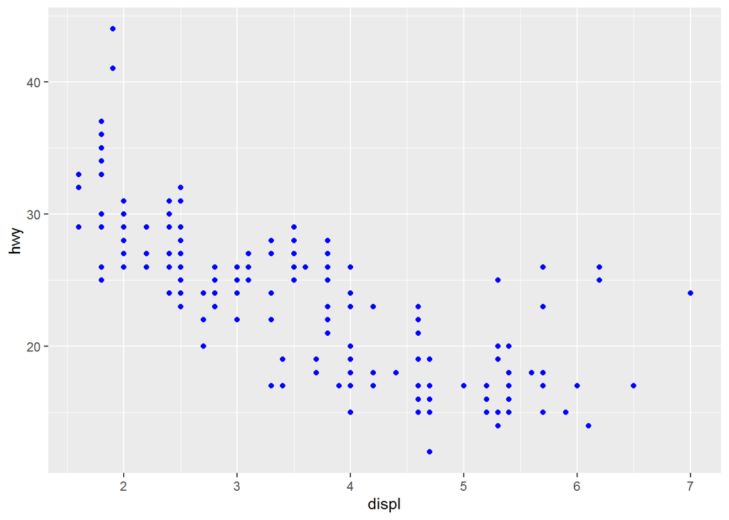

```r
ggplot(data = mpg) +
  geom_point(mapping = aes(x = displ, y = hwy), color = "blue")
```

*1.3.1 연습문제*

1. 다음의 코드는 무엇이 문제인가? 점들이 왜 파란색이 아닌가?

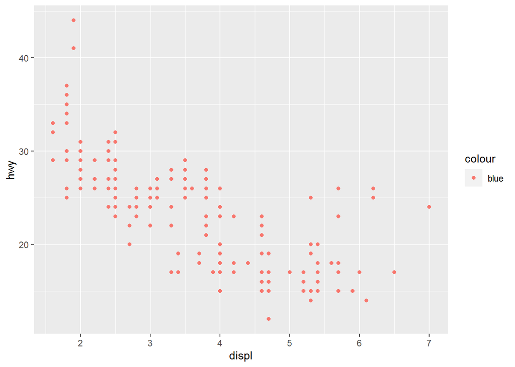

```r
ggplot(data = mpg) +
  geom_point(
    mapping = aes(x = displ, y = hwy, color = "blue")
  )
```

2. mpg의 어느 변수가 범주형인가? 어떤 변수가 연속형인가? (힌트: ?mpg를 타이핑하여 - 해당 데이터셋에 대한 설명서를 읽어보라)mpg를 실행할 때 이 정보를 어떻게 볼 수 있는가?
3. 연속형 변수 하나를 color, size, shape로 매핑하라. 이러한 심미성은 범주형, 연속형 변수에 따라 어떻게 다르게 작동하는가?
4. 하나의 변수를 여러 심미성에 매핑하면 어떻게 되는가?
5. stroke 심미성의 역할은 무엇인가? 어떤 모양과 함께 작동하는가?(힌트 : ?geom_point를 사용하라.)
6. aes(color = displ < 5 )처럼 심미성을 변수 이름이 아닌 다른 것에 매핑하면 어떻게 되는가?

## 1.4 자주 일어나는 문제들

```
  ggplot(data = mpg)
   + geom_point(mapping = aes(x = displ, y = hwy))
```

- +는 항상 첫 줄에 와야한다.
- ?를 활용해 도움말을 확인하자
- 오류메세지를 구글에 검색해보자.

## 1.5 facet

- 범주형 변수에서는 플롯을 **면분할(facet, 데이터 각 서브셋을 표시하는 하위 플롯)**로 나누는 것이 유용하다.
- 플롯을 하나의 변수에 대해 면분할하기 위해서는 **facet_wrap()**을 이용하면 된다.
- facet_wrap()은 **이산형**이어야 한다.
- *이산형 변수* : 값이 문자형이나 정수형처럼 서로 떨어져 있는 유형을 의미하며, 연속형과 대비되는 용어이다.

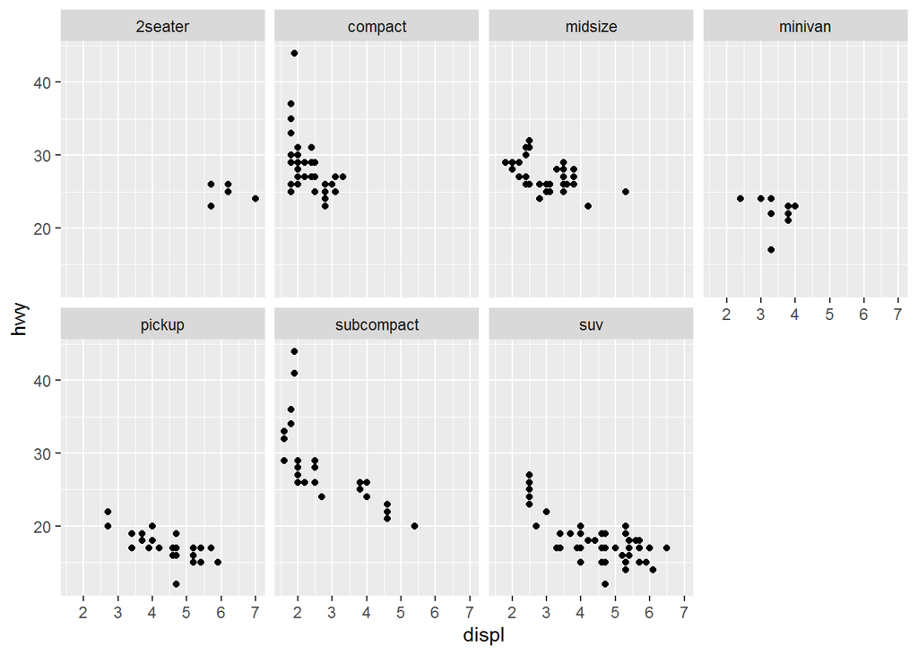

```r
ggplot(data = mpg) +
  geom_point(mapping = aes(x = displ, y = hwy)) +
  facet_wrap(~ class, nrow =2)
```

- 위의 코드에서 마지막 줄의 facet_wrap( ~ class, **nrow = 2**), 여기서 **nrow**는 : Number of rows and columns. 즉, 내가 이 그래프의 행 또는 열의 개수를 정할 수 있다는 뜻입니다.

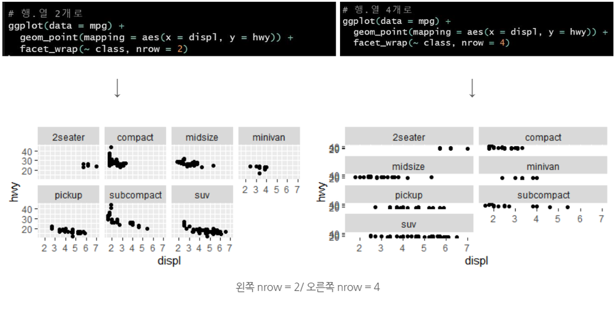

nrow

- 플롯을 두 변수 조합으로 면분할하기 위해서는 **facet_grid()**을 사용하면 유용하다.

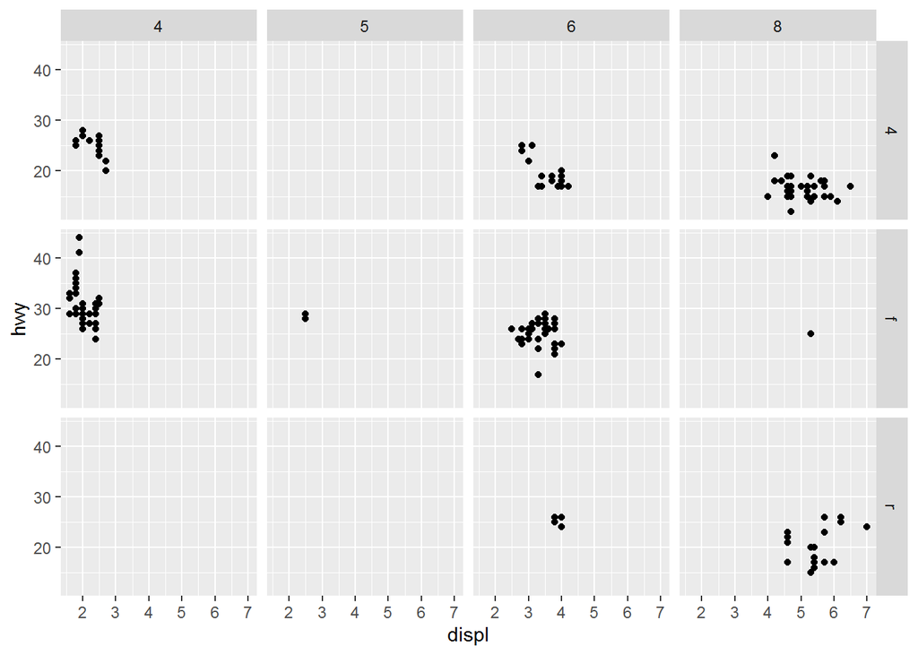

```r
ggplot(data = mpg) +
  geom_point(mapping = aes(x = displ, y = hwy)) +
  facet_grid(drv ~ cyl)
```

- 열이나 행으로 면분할하고 싶지 않다면 변수 이름 대신 **.** 을 이용해라

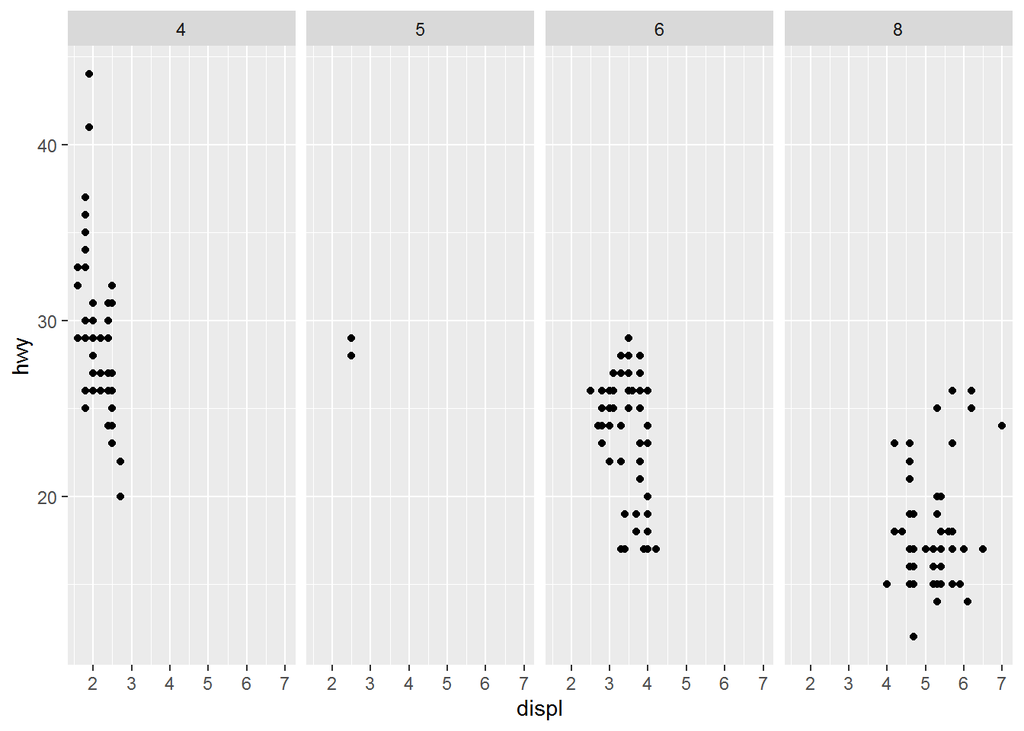

```r
ggplot(data = mpg) +
  geom_point(mapping = aes(x = displ, y = hwy)) +       facet_grid(. ~ cyl)
```

- ?facet_wrap “면분할”
- ?facet_grid 플롯을 ‘두 가지’ 변수 조합으로 면분할 > >

*1.5.1 연습문제*

1. 연속형 변수로 면분할하면 어떻게 되는가?
2. facet_grid(dvr ~cyl)로 만든 플롯에 있는 빈셀들은 무엇을 의미하는가? 다음의 플롯과 어떻게 연관되는가?

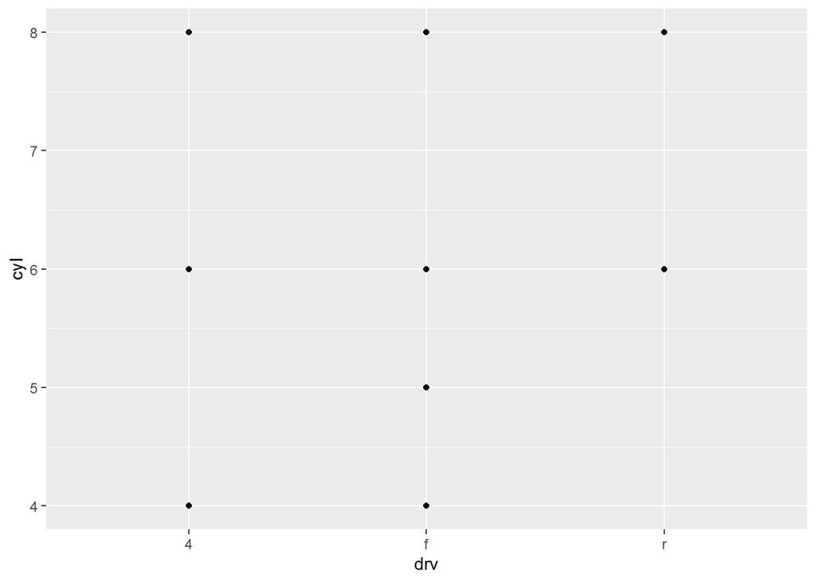

```r
ggplot(data = mpg) +
  geom_point(mapping = aes(x = drv, y = cyl))
```

3. 다음의 코드는 어떤 플롯을 만드는가? .은 어떤 역할을 하는가?

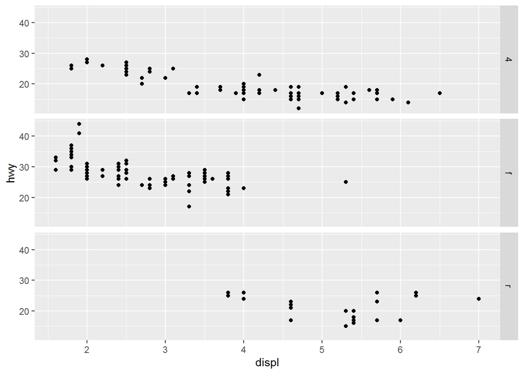

```r
ggplot(data = mpg) +
  geom_point(mapping = aes(x = displ, y = hwy)) +
  facet_grid(drv ~ .)
```

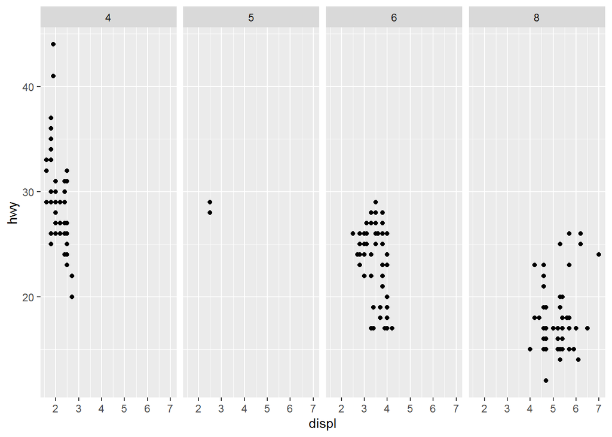

```r
ggplot(data = mpg) +
  geom_point(mapping = aes(x = displ, y = hwy)) +
  facet_grid(. ~ cyl)
```

4. 이 절의 면불할된 첫 번째 플롯을 살펴보라.

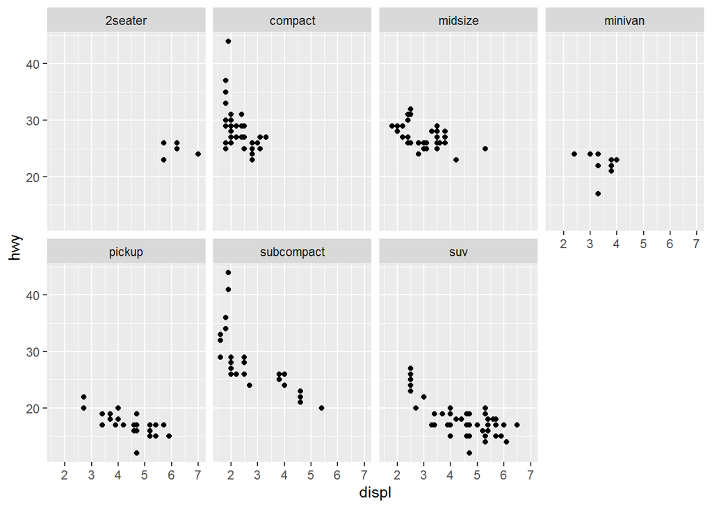

```r
ggplot(data = mpg) +
  geom_point(mapping = aes(x = displ, y = hwy)) +
  facet_wrap(~ class, nrow = 2)
```

색상 심미성을 쓰지 않고 면분할하면 어떤 이점이 있는가? 단점은 무엇인가? 데이터가 더 크다면 이 균형은 어떻게 바뀌겠는가?

5. ?facet_wrap을 읽어라. nrow의 역할은 무엇인가? ncol은 어떤 일을 하는가? 개별 패널의 배치를 조정할 수 있는 다른 바아법은 무엇인가? facet_grid()에는 nrow, ncol 인수가 왜 없는가?
6. facet_grid()를 사용할 때, 대개의 경우 고유 수준이 더 많은 변수를 열로 두어야 한다. 왜인가?

## 1.6 기하 객체

```r
ggplot(data = mpg) +
  geom_point(mapping = aes(x = displ, y = hwy))
```

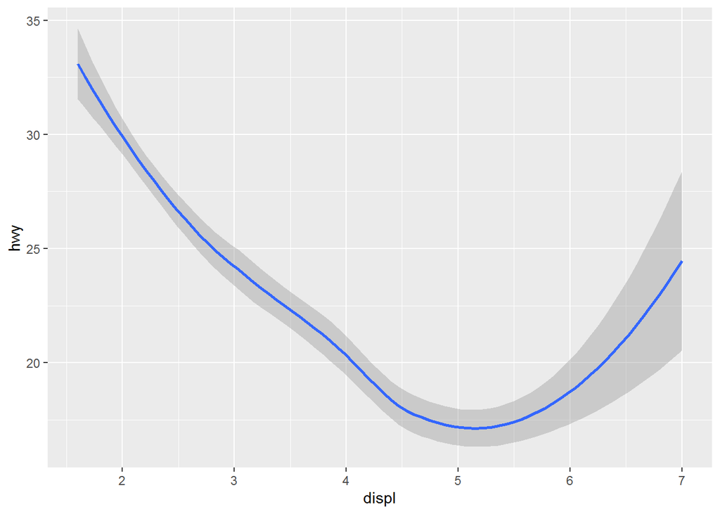

```r
ggplot(data = mpg) +
  geom_smooth(mapping = aes(x = displ, y = hwy))
```

- 지옴은 데이터를 나타내기 위해 플롯이 사용하는 기하 객체(geometrix object)를 의미한다.
- ggplot2의 모든 지옴 함수는 mapping 인수를 가진다.
- 점의 sharpe(모양)을 설정할 수 있지만, 선의 ’shape’은 설정할 수 없다.
- 선의 linetype(선유형)을 설정할 수 있다.

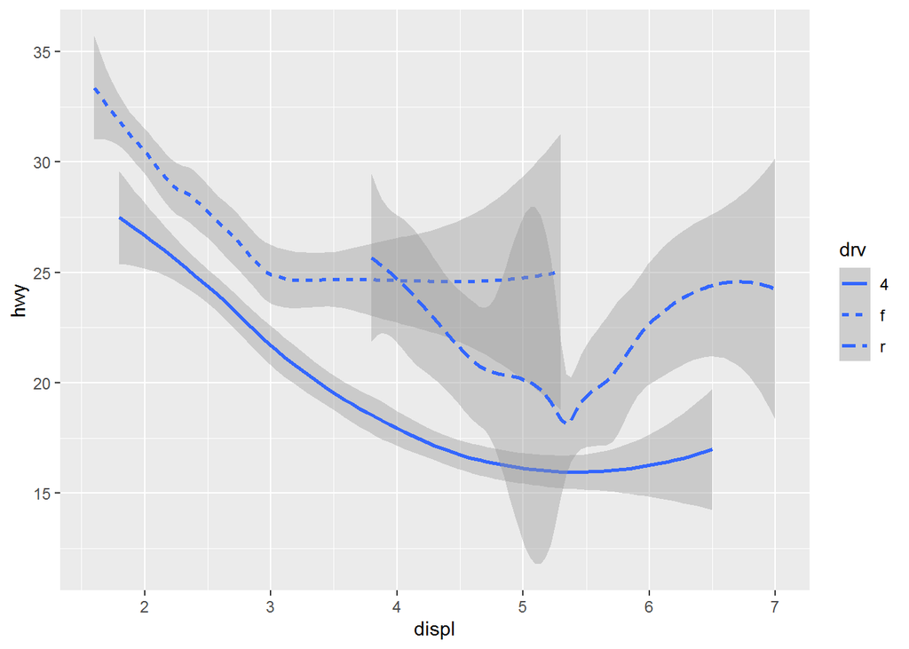

```r
ggplot(data = mpg) +
  geom_smooth(mapping = aes(x = displ, y = hwy,         linetype = drv))
```

- 4는 사륜구동, f는 전륜구동, r은 후륜구동을 나타낸다.
- 여기에 색깔까지 입혀주면 보기 더 좋다.

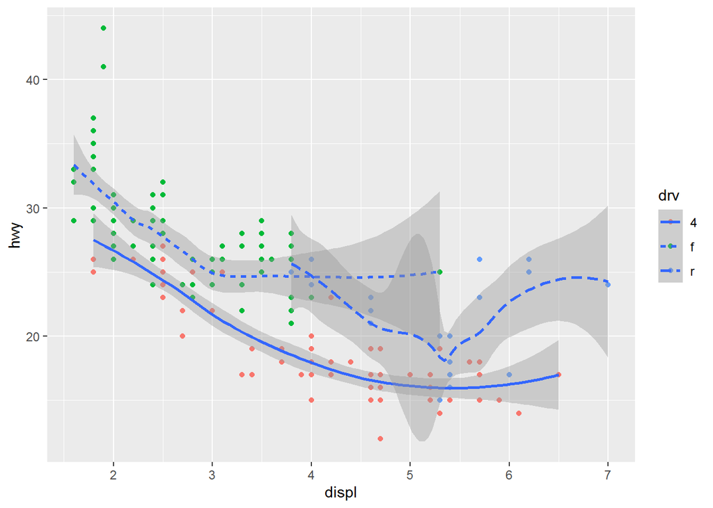

```r
ggplot(data = mpg, mapping = aes(x = displ, y = hwy)) +
  geom_point(mapping = aes(color = drv)) +
  geom_smooth(mapping = aes(linetype = drv))
```

- 그룹 심미성은 기본적으로 범례를 추가하거나 구별시켜주는 기능들을 추가하지 않기 때문에, 이 기능을 활용하면 편리하다.

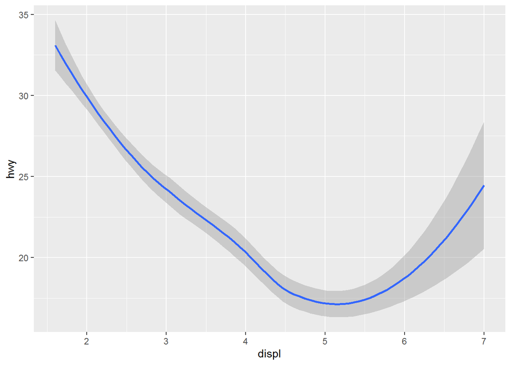

```r
ggplot(data = mpg) +
  geom_smooth(mapping = aes(x = displ, y = hwy))
```

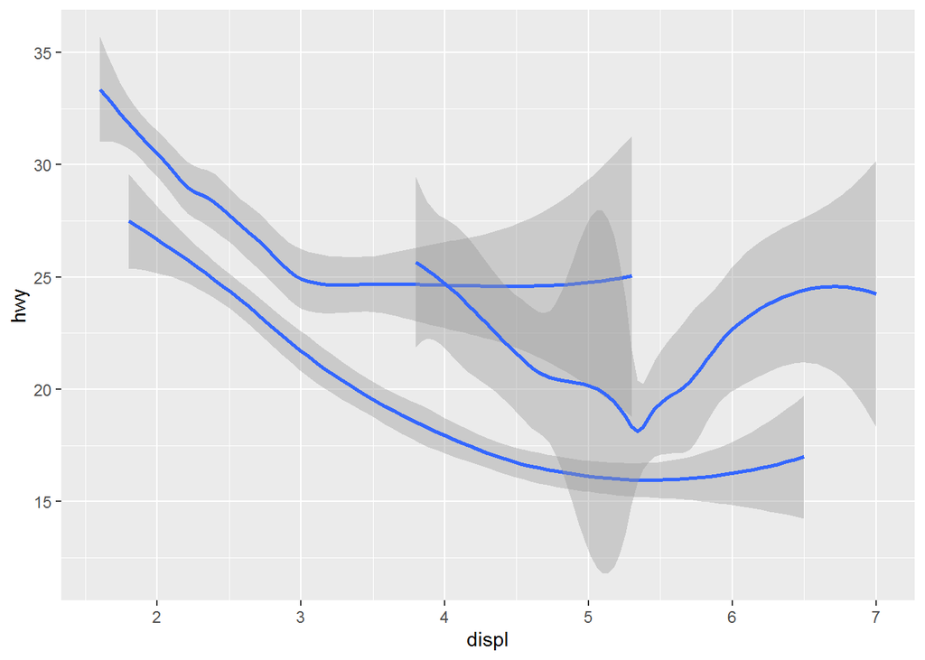

```r
ggplot(data = mpg) +
  geom_smooth(mapping = aes(x = displ, y = hwy, group = drv))
```

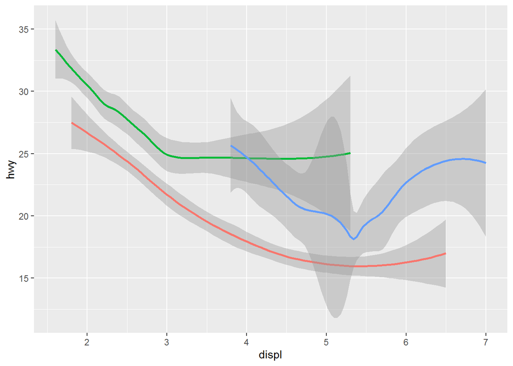

```r
ggplot(data = mpg) +
  geom_smooth(mapping = aes(x = displ, y = hwy, color = drv), show.legend = FALSE)
```

- 같은 플롯에 여러 지옴을 표시하려면 ggplot()에 여러 지옴 함수를 추가하라.

```r
ggplot(data = mpg) +
  geom_point(mapping = aes(x = displ, y = hwy)) +
  geom_smooth(mapping = aes(x = displ, y = hwy))
```

- 하지만 이렇게하면 불필요하게 코드가 중복해서 들어가므로 이를 **ggplot()에 넣어 묶어주면 전역 매핑**이 되어 간편하다.

```r
ggplot(data = mpg, mapping = aes(x = displ, y = hwy)) +
  geom_point() +
  geom_smooth()
```

- 다른 레이어마다 다른 심미성을 표시하는 것이 가능하다.

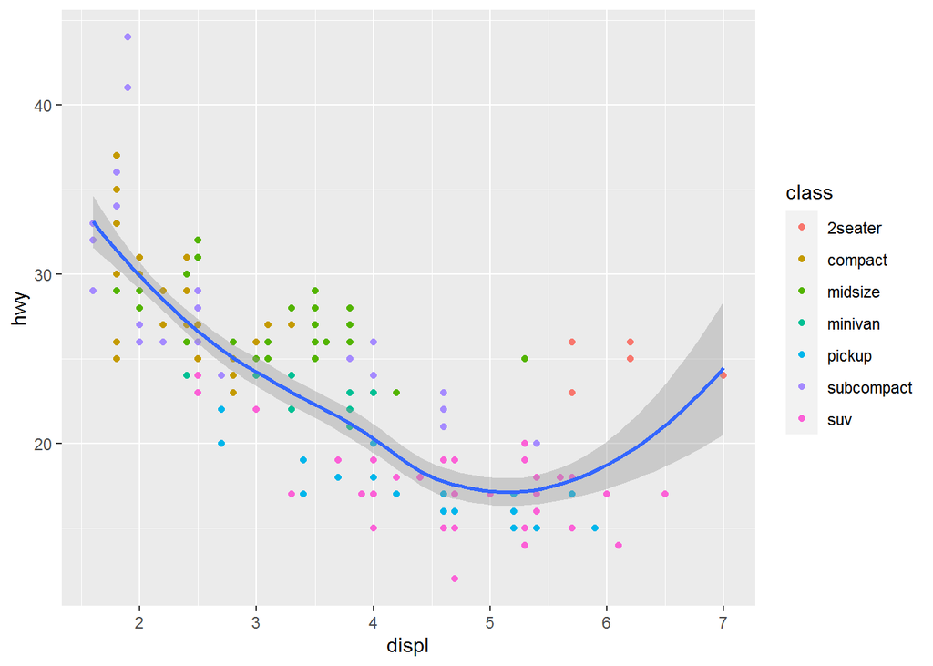

```r
ggplot(data = mpg, mapping = aes(x = displ, y = hwy)) +
  geom_point(mapping = aes(color = class)) +
  geom_smooth()
```

- 같은 원리로 레이어마다 다른 데이터를 지정할 수 있다.

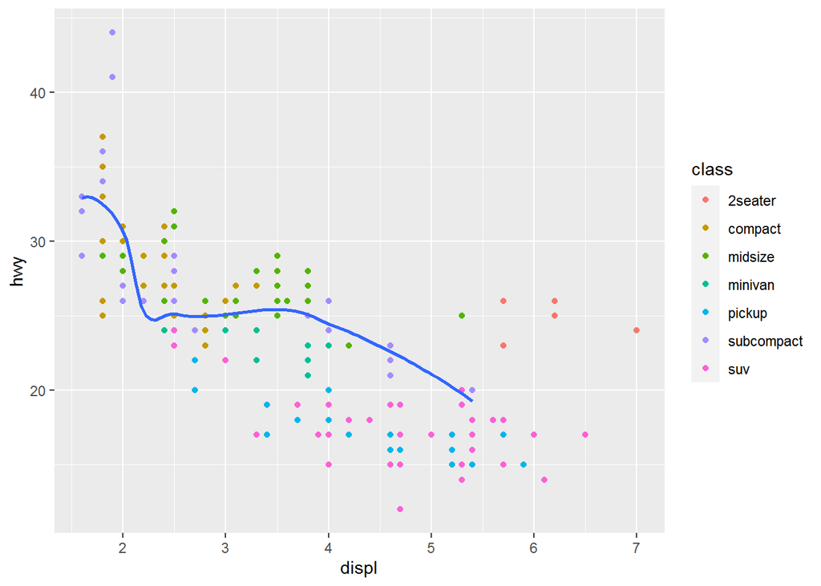

```r
library(ggplot2)
library(dplyr)
ggplot(data = mpg, mapping = aes(x = displ, y = hwy)) +
     geom_point(mapping = aes(color = class)) +
     geom_smooth(data = filter(mpg, class == "subcompact"), se = FALSE)
```

- filter를 넣음으로서 “subcompact”만 선택

*1.6.1 연습문제*

1. 선 그래프를 그리기 위해 어떤 지옴을 사용하겠는가? 박스 플롯을 그리려면? 히스토그램은? 면적(area)차트는?
2. 머릿속으로 다음의 코드를 실행하고 출력이 어떨지 예측해보라. 그럼 다음 R에서 코드를 실행하고 여러분의 예측을 확인하라.

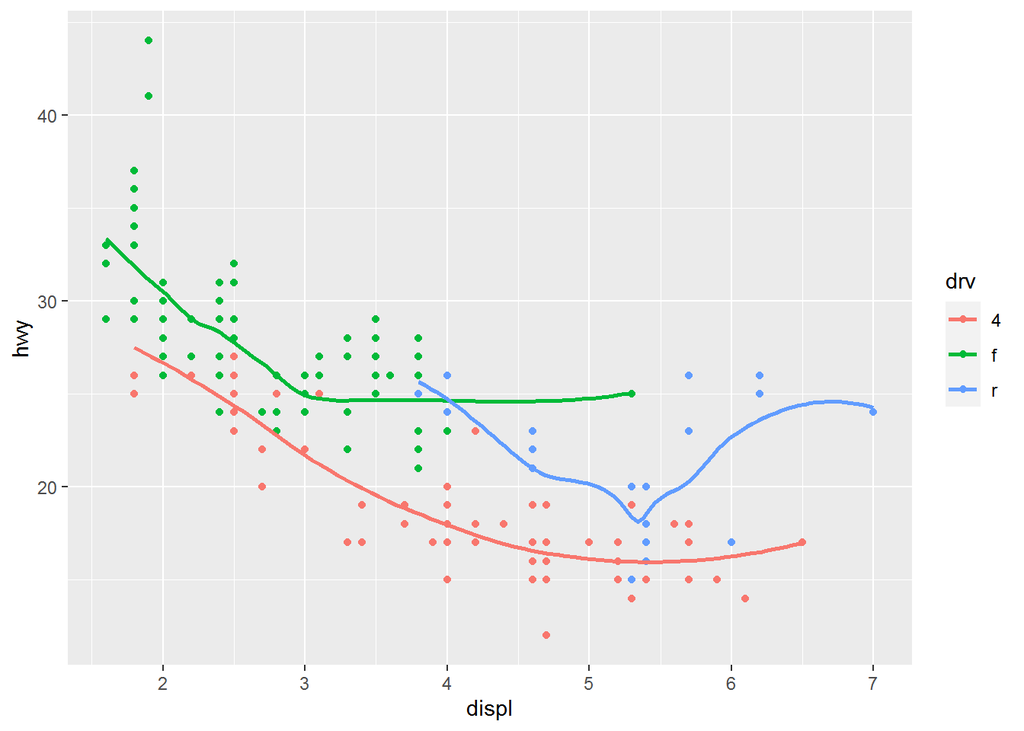

```r
ggplot(data = mpg, mapping = aes(x = displ, y = hwy, color = drv)) +
  geom_point() +
  geom_smooth(se = FALSE)
```

3. show.legend = FALSE는 어떤 역할을 하는가? 삭제하면 어떻게 되는가? 앞에서 왜 이를 사용했겠는가?
4. **geom_smooth() se 인수는 어떤 역할을 하는가?**

   Standard error(표준오차)를 의미한다.
5. 다음의 두 그래프는 다르게 나타나겠는가? 왜 그런가 or 그렇지 않은가?

```r
ggplot(data = mpg, mapping = aes(x = displ, y = hwy)) +
  geom_point() +
  geom_smooth()
ggplot() +
  geom_point(data = mpg, mapping = aes(x = displ, y = hwy)) +
  geom_smooth(data = mpg, mapping = aes(x = displ, y = hwy))
```

6. 다음의 그래프들을 생성하는 데 필요한 R코드를 다시 작성하라.

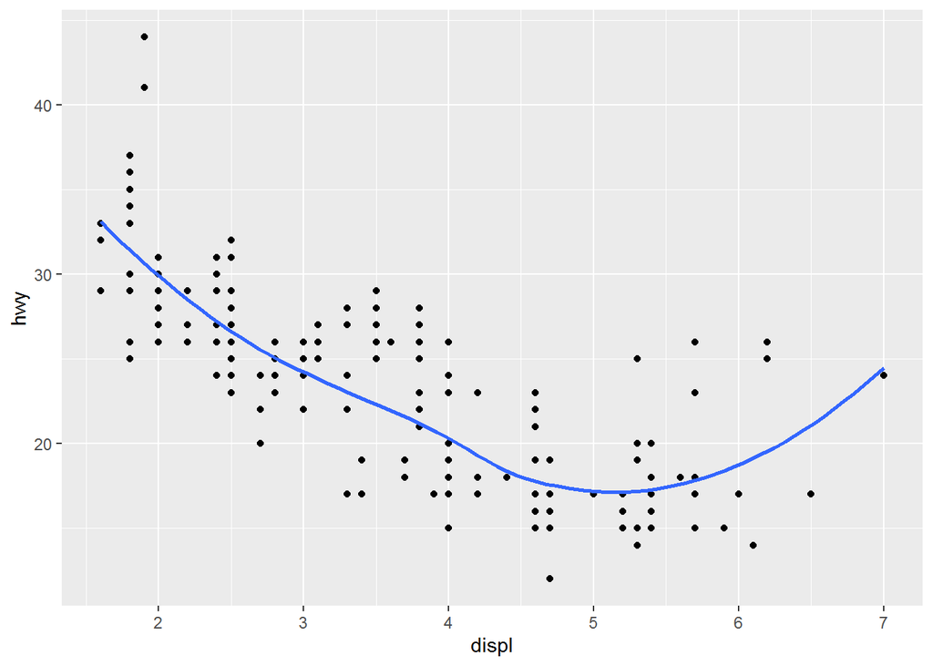

```r
ggplot(data = mpg, mapping = aes(x = displ, y = hwy)) +
      geom_point() +
      geom_smooth(se = FALSE)
```

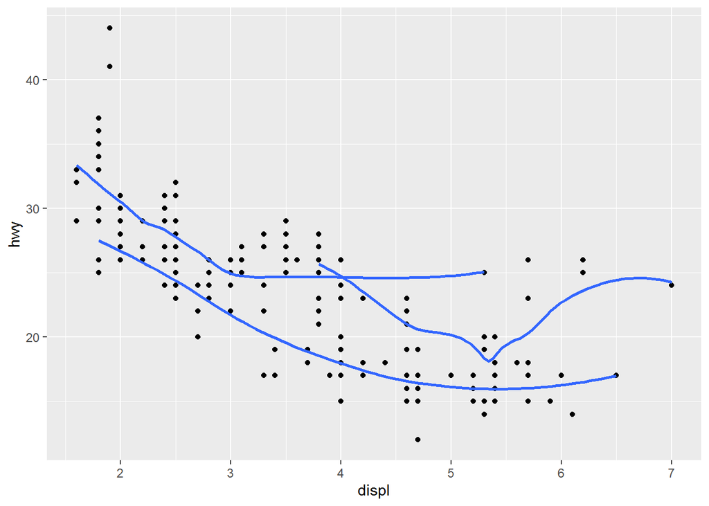

```r
ggplot(data = mpg, mapping = aes(x = displ, y = hwy)) +
      geom_point() +
      geom_smooth(mapping = aes(group = drv), se = FALSE)
```

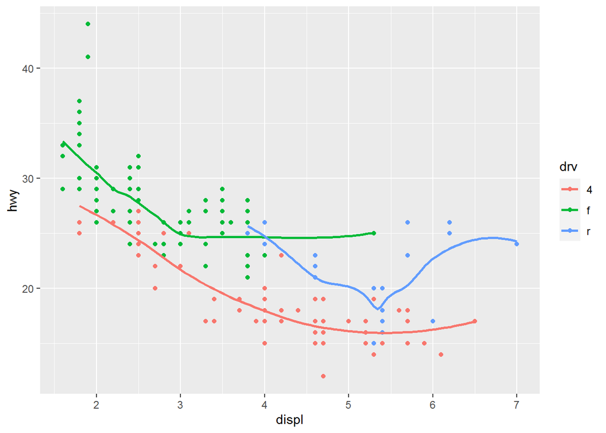

```r
ggplot(data = mpg, mapping = aes(x = displ, y = hwy)) +
      geom_point(mapping = aes(color = drv)) +
      geom_smooth(mapping = aes(color = drv), se = FALSE)
```

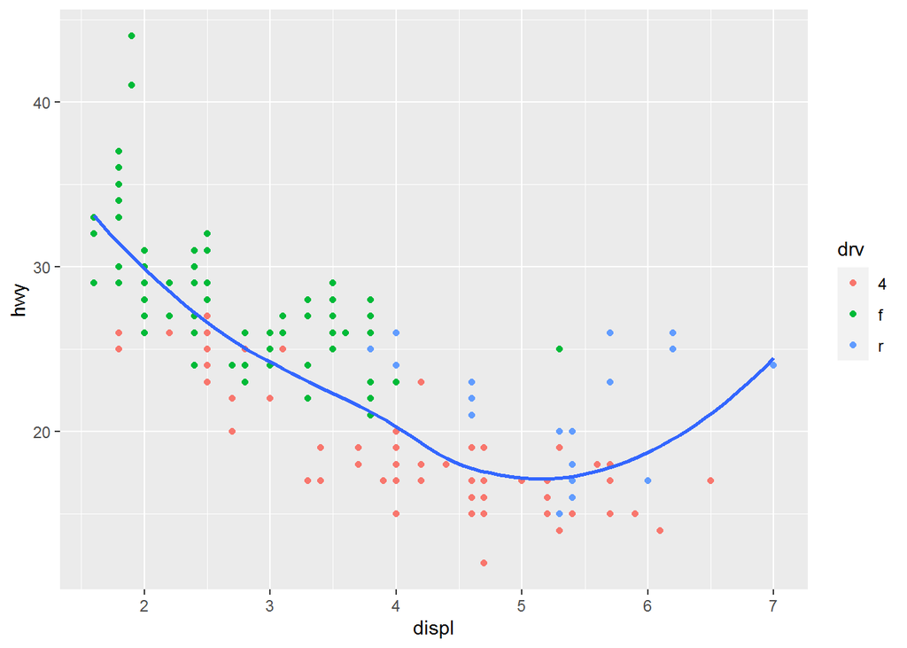

```r
ggplot(data = mpg, mapping = aes(x = displ, y = hwy)) +
      geom_point(mapping = aes(color = drv)) +
      geom_smooth(se = FALSE)
```

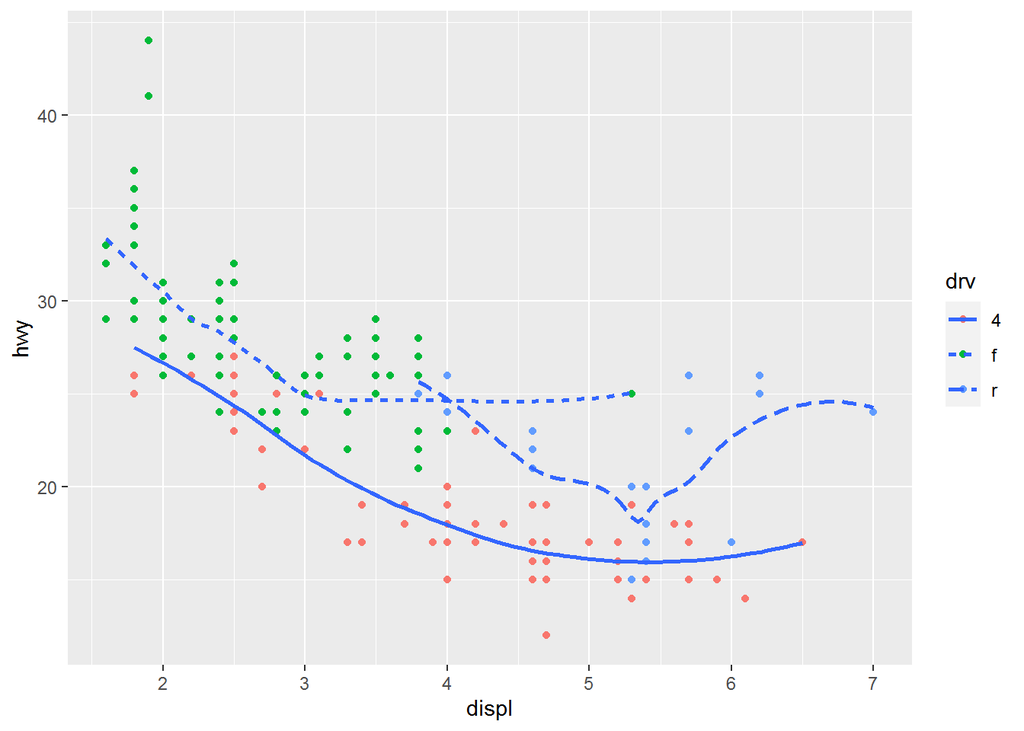

```r
ggplot(data = mpg, mapping = aes(x = displ, y = hwy)) +
      geom_point(mapping = aes(color = drv)) +
      geom_smooth(mapping = aes(linetype = drv), se = FALSE)
```

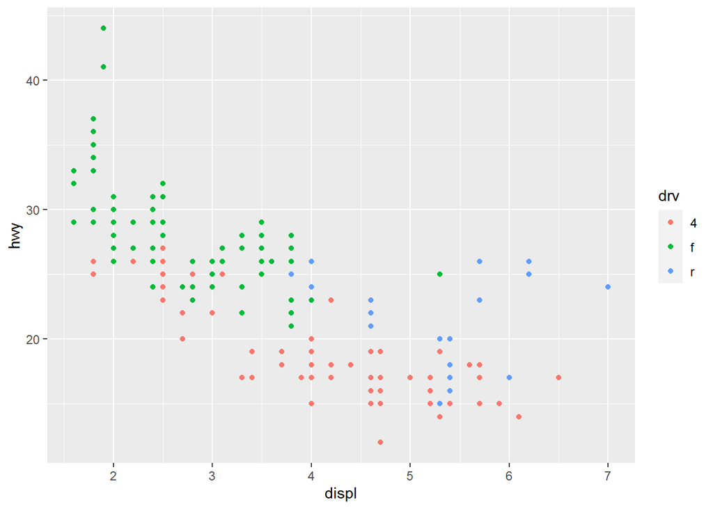

```
 #마지막 그래프는 잘모르겠...
```

```r
ggplot(data = mpg, mapping = aes(x = displ, y = hwy)) +
      geom_point(mapping = aes(color = drv), se = FALSE)
```